# Risk Factor Analysis

## Outcome Variable

**Outcome Variable:** ever_co

## Predictor Variables

**Intervention Variable:** gagebrth

**Adjustment Set:**

- arm
- sex
- W_mage
- meducyrs
- feducyrs
- hhwealth_quart
- W_nchldlt5
- brthmon
- W_parity
- impsan
- delta_W_mage
- delta_meducyrs
- delta_feducyrs
- delta_hhwealth_quart
- delta_W_nchldlt5
- delta_brthmon
- delta_W_parity
- delta_impsan

## Stratifying Variables

The analysis was stratified on these variable(s):

- agecat
- studyid
- country

## Data Summary

| agecat | studyid | country | gagebrth | ever_co | n_cell | n |
| --- | --- | --- | --- | --- | --- | --- |
| 0-24 months | ki1000108-CMC-V-BCS-2002 | INDIA | Full or late term | 0 | 170 | 351 |
| 0-24 months | ki1000108-CMC-V-BCS-2002 | INDIA | Full or late term | 1 | 45 | 351 |
| 0-24 months | ki1000108-CMC-V-BCS-2002 | INDIA | Preterm | 0 | 35 | 351 |
| 0-24 months | ki1000108-CMC-V-BCS-2002 | INDIA | Preterm | 1 | 17 | 351 |
| 0-24 months | ki1000108-CMC-V-BCS-2002 | INDIA | Early term | 0 | 70 | 351 |
| 0-24 months | ki1000108-CMC-V-BCS-2002 | INDIA | Early term | 1 | 14 | 351 |
| 0-24 months | ki1000108-IRC | INDIA | Full or late term | 0 | 211 | 390 |
| 0-24 months | ki1000108-IRC | INDIA | Full or late term | 1 | 39 | 390 |
| 0-24 months | ki1000108-IRC | INDIA | Preterm | 0 | 28 | 390 |
| 0-24 months | ki1000108-IRC | INDIA | Preterm | 1 | 14 | 390 |
| 0-24 months | ki1000108-IRC | INDIA | Early term | 0 | 78 | 390 |
| 0-24 months | ki1000108-IRC | INDIA | Early term | 1 | 20 | 390 |
| 0-24 months | ki1000109-EE | PAKISTAN | Full or late term | 0 | 13 | 379 |
| 0-24 months | ki1000109-EE | PAKISTAN | Full or late term | 1 | 4 | 379 |
| 0-24 months | ki1000109-EE | PAKISTAN | Preterm | 0 | 155 | 379 |
| 0-24 months | ki1000109-EE | PAKISTAN | Preterm | 1 | 147 | 379 |
| 0-24 months | ki1000109-EE | PAKISTAN | Early term | 0 | 41 | 379 |
| 0-24 months | ki1000109-EE | PAKISTAN | Early term | 1 | 19 | 379 |
| 0-24 months | ki1017093c-NIH-Crypto | BANGLADESH | Full or late term | 0 | 161 | 758 |
| 0-24 months | ki1017093c-NIH-Crypto | BANGLADESH | Full or late term | 1 | 7 | 758 |
| 0-24 months | ki1017093c-NIH-Crypto | BANGLADESH | Preterm | 0 | 224 | 758 |
| 0-24 months | ki1017093c-NIH-Crypto | BANGLADESH | Preterm | 1 | 41 | 758 |
| 0-24 months | ki1017093c-NIH-Crypto | BANGLADESH | Early term | 0 | 302 | 758 |
| 0-24 months | ki1017093c-NIH-Crypto | BANGLADESH | Early term | 1 | 23 | 758 |
| 0-24 months | ki1066203-TanzaniaChild2 | TANZANIA, UNITED REPUBLIC OF | Full or late term | 0 | 1334 | 2254 |
| 0-24 months | ki1066203-TanzaniaChild2 | TANZANIA, UNITED REPUBLIC OF | Full or late term | 1 | 56 | 2254 |
| 0-24 months | ki1066203-TanzaniaChild2 | TANZANIA, UNITED REPUBLIC OF | Preterm | 0 | 321 | 2254 |
| 0-24 months | ki1066203-TanzaniaChild2 | TANZANIA, UNITED REPUBLIC OF | Preterm | 1 | 29 | 2254 |
| 0-24 months | ki1066203-TanzaniaChild2 | TANZANIA, UNITED REPUBLIC OF | Early term | 0 | 487 | 2254 |
| 0-24 months | ki1066203-TanzaniaChild2 | TANZANIA, UNITED REPUBLIC OF | Early term | 1 | 27 | 2254 |

[output cut: 168 more lines]

The following strata were considered:

- agecat: 0-24 months, studyid: ki1000108-CMC-V-BCS-2002, country: INDIA
- agecat: 0-24 months, studyid: ki1000108-IRC, country: INDIA
- agecat: 0-24 months, studyid: ki1000109-EE, country: PAKISTAN
- agecat: 0-24 months, studyid: ki1017093c-NIH-Crypto, country: BANGLADESH
- agecat: 0-24 months, studyid: ki1066203-TanzaniaChild2, country: TANZANIA, UNITED REPUBLIC OF
- agecat: 0-24 months, studyid: ki1101329-Keneba, country: GAMBIA
- agecat: 0-24 months, studyid: ki1119695-PROBIT, country: BELARUS
- agecat: 0-24 months, studyid: ki1135781-COHORTS, country: GUATEMALA
- agecat: 0-24 months, studyid: ki1135781-COHORTS, country: INDIA
- agecat: 0-24 months, studyid: ki1135781-COHORTS, country: PHILIPPINES
- agecat: 0-24 months, studyid: kiGH5241-JiVitA-3, country: BANGLADESH
- agecat: 0-6 months, studyid: ki1000108-CMC-V-BCS-2002, country: INDIA
- agecat: 0-6 months, studyid: ki1000108-IRC, country: INDIA
- agecat: 0-6 months, studyid: ki1000109-EE, country: PAKISTAN
- agecat: 0-6 months, studyid: ki1017093c-NIH-Crypto, country: BANGLADESH
- agecat: 0-6 months, studyid: ki1066203-TanzaniaChild2, country: TANZANIA, UNITED REPUBLIC OF
- agecat: 0-6 months, studyid: ki1101329-Keneba, country: GAMBIA
- agecat: 0-6 months, studyid: ki1119695-PROBIT, country: BELARUS
- agecat: 0-6 months, studyid: ki1135781-COHORTS, country: GUATEMALA
- agecat: 0-6 months, studyid: ki1135781-COHORTS, country: INDIA
- agecat: 0-6 months, studyid: ki1135781-COHORTS, country: PHILIPPINES
- agecat: 0-6 months, studyid: kiGH5241-JiVitA-3, country: BANGLADESH
- agecat: 6-24 months, studyid: ki1000108-CMC-V-BCS-2002, country: INDIA
- agecat: 6-24 months, studyid: ki1000108-IRC, country: INDIA
- agecat: 6-24 months, studyid: ki1000109-EE, country: PAKISTAN
- agecat: 6-24 months, studyid: ki1017093c-NIH-Crypto, country: BANGLADESH
- agecat: 6-24 months, studyid: ki1066203-TanzaniaChild2, country: TANZANIA, UNITED REPUBLIC OF
- agecat: 6-24 months, studyid: ki1101329-Keneba, country: GAMBIA
- agecat: 6-24 months, studyid: ki1119695-PROBIT, country: BELARUS
- agecat: 6-24 months, studyid: ki1135781-COHORTS, country: GUATEMALA
- agecat: 6-24 months, studyid: ki1135781-COHORTS, country: INDIA
- agecat: 6-24 months, studyid: ki1135781-COHORTS, country: PHILIPPINES
- agecat: 6-24 months, studyid: kiGH5241-JiVitA-3, country: BANGLADESH

### Dropped Strata

Some strata were dropped due to rare outcomes:

- agecat: 0-24 months, studyid: ki1000109-EE, country: PAKISTAN
- agecat: 0-24 months, studyid: ki1119695-PROBIT, country: BELARUS
- agecat: 0-6 months, studyid: ki1000109-EE, country: PAKISTAN
- agecat: 0-6 months, studyid: ki1017093c-NIH-Crypto, country: BANGLADESH
- agecat: 0-6 months, studyid: ki1066203-TanzaniaChild2, country: TANZANIA, UNITED REPUBLIC OF
- agecat: 0-6 months, studyid: ki1119695-PROBIT, country: BELARUS
- agecat: 6-24 months, studyid: ki1000109-EE, country: PAKISTAN
- agecat: 6-24 months, studyid: ki1119695-PROBIT, country: BELARUS

## Methods Detail

We’re interested in the causal parameters $E[Y_a]$ for all values of $a \in \mathcal{A}$. These parameters represent the mean outcome if, possibly contrary to fact, we intervened to set all units to have $A=a$. Under the randomization and positivity assumptions, these are identified by the statistical parameters $\psi_a=E_W[E_{Y|A,W}(Y|A=a,W)]$. In addition, we’re interested in the mean of $Y$, $E[Y]$ under no intervention (the observed mean). We will estimate these parameters by using SuperLearner to fit the relevant likelihood factors – $E_{Y|A,W}(Y|A=a,W)$ and $p(A=a|W)$, and then updating our likelihood fit using a joint TMLE.

For unadjusted analyses ($W=\{\}$), initial likelihoods were estimated using Lrnr_glm to estimate the simple $E(Y|A)$ and Lrnr_mean to estimate $p(A)$. For adjusted analyses, a small library containing Lrnr_glmnet, Lrnr_xgboost, and Lrnr_mean was used.

Having estimated these parameters, we will then use the delta method to estimate relative risks and attributable risks relative to a prespecified baseline level of $A$.

# Results Detail

## Results Plots

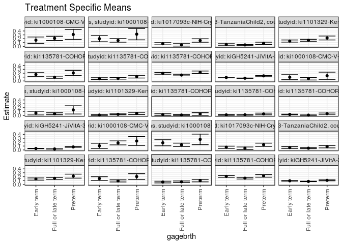

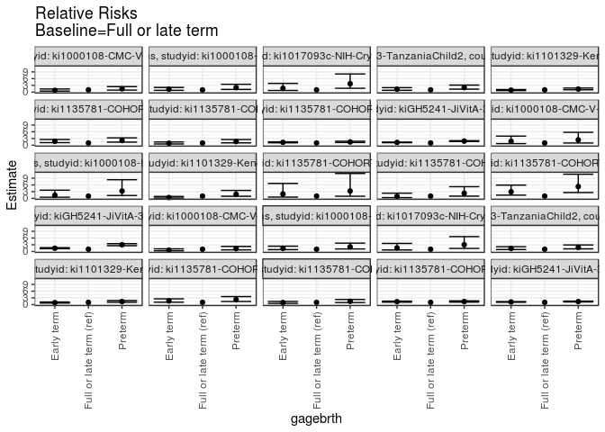

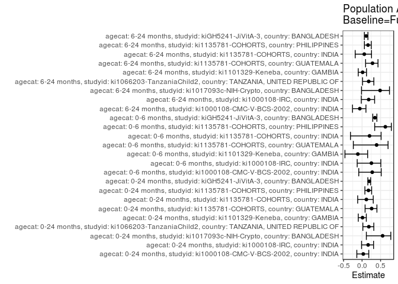

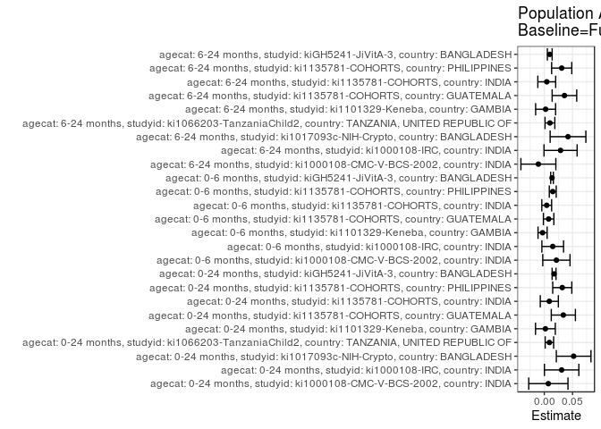

## Results Table

### Parameter: TSM

| agecat | studyid | country | intervention_level | baseline_level | estimate | ci_lower | ci_upper |
| --- | --- | --- | --- | --- | --- | --- | --- |
| 0-24 months | ki1000108-CMC-V-BCS-2002 | INDIA | Full or late term | NA | 0.2093257 | 0.1545819 | 0.2640696 |
| 0-24 months | ki1000108-CMC-V-BCS-2002 | INDIA | Preterm | NA | 0.3093701 | 0.1780580 | 0.4406821 |
| 0-24 months | ki1000108-CMC-V-BCS-2002 | INDIA | Early term | NA | 0.1637636 | 0.0822823 | 0.2452448 |
| 0-24 months | ki1000108-IRC | INDIA | Full or late term | NA | 0.1564647 | 0.1111959 | 0.2017336 |
| 0-24 months | ki1000108-IRC | INDIA | Preterm | NA | 0.3172317 | 0.1711401 | 0.4633233 |
| 0-24 months | ki1000108-IRC | INDIA | Early term | NA | 0.2006007 | 0.1214154 | 0.2797859 |
| 0-24 months | ki1017093c-NIH-Crypto | BANGLADESH | Full or late term | NA | 0.0416667 | 0.0114301 | 0.0719033 |
| 0-24 months | ki1017093c-NIH-Crypto | BANGLADESH | Preterm | NA | 0.1547170 | 0.1111476 | 0.1982864 |
| 0-24 months | ki1017093c-NIH-Crypto | BANGLADESH | Early term | NA | 0.0707692 | 0.0428710 | 0.0986675 |
| 0-24 months | ki1066203-TanzaniaChild2 | TANZANIA, UNITED REPUBLIC OF | Full or late term | NA | 0.0406089 | 0.0302171 | 0.0510006 |
| 0-24 months | ki1066203-TanzaniaChild2 | TANZANIA, UNITED REPUBLIC OF | Preterm | NA | 0.0823755 | 0.0535616 | 0.1111894 |
| 0-24 months | ki1066203-TanzaniaChild2 | TANZANIA, UNITED REPUBLIC OF | Early term | NA | 0.0516689 | 0.0324538 | 0.0708839 |
| 0-24 months | ki1101329-Keneba | GAMBIA | Full or late term | NA | 0.1599716 | 0.1352192 | 0.1847240 |
| 0-24 months | ki1101329-Keneba | GAMBIA | Preterm | NA | 0.2196727 | 0.1692779 | 0.2700676 |
| 0-24 months | ki1101329-Keneba | GAMBIA | Early term | NA | 0.1409390 | 0.1133122 | 0.1685658 |
| 0-24 months | ki1135781-COHORTS | GUATEMALA | Full or late term | NA | 0.0967866 | 0.0695201 | 0.1240531 |
| 0-24 months | ki1135781-COHORTS | GUATEMALA | Preterm | NA | 0.2063590 | 0.1381523 | 0.2745657 |
| 0-24 months | ki1135781-COHORTS | GUATEMALA | Early term | NA | 0.1666494 | 0.1195376 | 0.2137612 |
| 0-24 months | ki1135781-COHORTS | INDIA | Full or late term | NA | 0.0676598 | 0.0471453 | 0.0881743 |
| 0-24 months | ki1135781-COHORTS | INDIA | Preterm | NA | 0.1108602 | 0.0759889 | 0.1457315 |
| 0-24 months | ki1135781-COHORTS | INDIA | Early term | NA | 0.0615175 | 0.0395448 | 0.0834902 |
| 0-24 months | ki1135781-COHORTS | PHILIPPINES | Full or late term | NA | 0.1526567 | 0.1320305 | 0.1732830 |
| 0-24 months | ki1135781-COHORTS | PHILIPPINES | Preterm | NA | 0.2252273 | 0.1934844 | 0.2569702 |
| 0-24 months | ki1135781-COHORTS | PHILIPPINES | Early term | NA | 0.1962237 | 0.1739585 | 0.2184889 |
| 0-24 months | kiGH5241-JiVitA-3 | BANGLADESH | Full or late term | NA | 0.0716420 | 0.0668722 | 0.0764118 |
| 0-24 months | kiGH5241-JiVitA-3 | BANGLADESH | Preterm | NA | 0.1314076 | 0.1212057 | 0.1416094 |
| 0-24 months | kiGH5241-JiVitA-3 | BANGLADESH | Early term | NA | 0.0903535 | 0.0832559 | 0.0974511 |
| 0-6 months | ki1000108-CMC-V-BCS-2002 | INDIA | Full or late term | NA | 0.0566038 | 0.0254523 | 0.0877552 |
| 0-6 months | ki1000108-CMC-V-BCS-2002 | INDIA | Preterm | NA | 0.1346154 | 0.0417130 | 0.2275178 |
| 0-6 months | ki1000108-CMC-V-BCS-2002 | INDIA | Early term | NA | 0.0975610 | 0.0332453 | 0.1618766 |
| 0-6 months | ki1000108-IRC | INDIA | Full or late term | NA | 0.0441767 | 0.0186207 | 0.0697327 |
| 0-6 months | ki1000108-IRC | INDIA | Preterm | NA | 0.1428571 | 0.0368927 | 0.2488215 |
| 0-6 months | ki1000108-IRC | INDIA | Early term | NA | 0.0612245 | 0.0136978 | 0.1087512 |
| 0-6 months | ki1101329-Keneba | GAMBIA | Full or late term | NA | 0.0295250 | 0.0176344 | 0.0414156 |
| 0-6 months | ki1101329-Keneba | GAMBIA | Preterm | NA | 0.0537190 | 0.0253038 | 0.0821343 |
| 0-6 months | ki1101329-Keneba | GAMBIA | Early term | NA | 0.0106383 | 0.0021688 | 0.0191078 |
| 0-6 months | ki1135781-COHORTS | GUATEMALA | Full or late term | NA | 0.0119048 | 0.0015255 | 0.0222840 |
| 0-6 months | ki1135781-COHORTS | GUATEMALA | Preterm | NA | 0.0387597 | 0.0054291 | 0.0720903 |
| 0-6 months | ki1135781-COHORTS | GUATEMALA | Early term | NA | 0.0231481 | 0.0030814 | 0.0432149 |
| 0-6 months | ki1135781-COHORTS | INDIA | Full or late term | NA | 0.0171821 | 0.0066207 | 0.0277436 |
| 0-6 months | ki1135781-COHORTS | INDIA | Preterm | NA | 0.0389610 | 0.0173428 | 0.0605792 |
| 0-6 months | ki1135781-COHORTS | INDIA | Early term | NA | 0.0152838 | 0.0040443 | 0.0265234 |
| 0-6 months | ki1135781-COHORTS | PHILIPPINES | Full or late term | NA | 0.0088549 | 0.0033732 | 0.0143367 |
| 0-6 months | ki1135781-COHORTS | PHILIPPINES | Preterm | NA | 0.0467408 | 0.0304050 | 0.0630766 |
| 0-6 months | ki1135781-COHORTS | PHILIPPINES | Early term | NA | 0.0256929 | 0.0167417 | 0.0346441 |
| 0-6 months | kiGH5241-JiVitA-3 | BANGLADESH | Full or late term | NA | 0.0258273 | 0.0230124 | 0.0286422 |
| 0-6 months | kiGH5241-JiVitA-3 | BANGLADESH | Preterm | NA | 0.0774155 | 0.0695651 | 0.0852660 |
| 0-6 months | kiGH5241-JiVitA-3 | BANGLADESH | Early term | NA | 0.0374338 | 0.0327311 | 0.0421365 |
| 6-24 months | ki1000108-CMC-V-BCS-2002 | INDIA | Full or late term | NA | 0.1813953 | 0.1298133 | 0.2329774 |
| 6-24 months | ki1000108-CMC-V-BCS-2002 | INDIA | Preterm | NA | 0.2307692 | 0.1160904 | 0.3454481 |
| 6-24 months | ki1000108-CMC-V-BCS-2002 | INDIA | Early term | NA | 0.1071429 | 0.0409059 | 0.1733798 |
| 6-24 months | ki1000108-IRC | INDIA | Full or late term | NA | 0.1326943 | 0.0903519 | 0.1750367 |
| 6-24 months | ki1000108-IRC | INDIA | Preterm | NA | 0.2716166 | 0.1353677 | 0.4078656 |
| 6-24 months | ki1000108-IRC | INDIA | Early term | NA | 0.1844433 | 0.1063923 | 0.2624943 |
| 6-24 months | ki1017093c-NIH-Crypto | BANGLADESH | Full or late term | NA | 0.0443038 | 0.0121970 | 0.0764106 |
| 6-24 months | ki1017093c-NIH-Crypto | BANGLADESH | Preterm | NA | 0.1333333 | 0.0915819 | 0.1750847 |
| 6-24 months | ki1017093c-NIH-Crypto | BANGLADESH | Early term | NA | 0.0694006 | 0.0414057 | 0.0973955 |
| 6-24 months | ki1066203-TanzaniaChild2 | TANZANIA, UNITED REPUBLIC OF | Full or late term | NA | 0.0458958 | 0.0338099 | 0.0579817 |
| 6-24 months | ki1066203-TanzaniaChild2 | TANZANIA, UNITED REPUBLIC OF | Preterm | NA | 0.0846006 | 0.0528541 | 0.1163472 |
| 6-24 months | ki1066203-TanzaniaChild2 | TANZANIA, UNITED REPUBLIC OF | Early term | NA | 0.0625722 | 0.0399069 | 0.0852374 |
| 6-24 months | ki1101329-Keneba | GAMBIA | Full or late term | NA | 0.1566653 | 0.1316866 | 0.1816439 |
| 6-24 months | ki1101329-Keneba | GAMBIA | Preterm | NA | 0.2137488 | 0.1624847 | 0.2650130 |
| 6-24 months | ki1101329-Keneba | GAMBIA | Early term | NA | 0.1390374 | 0.1110336 | 0.1670413 |
| 6-24 months | ki1135781-COHORTS | GUATEMALA | Full or late term | NA | 0.0907795 | 0.0633206 | 0.1182383 |
| 6-24 months | ki1135781-COHORTS | GUATEMALA | Preterm | NA | 0.2028239 | 0.1293343 | 0.2763134 |
| 6-24 months | ki1135781-COHORTS | GUATEMALA | Early term | NA | 0.1513305 | 0.1037979 | 0.1988632 |
| 6-24 months | ki1135781-COHORTS | INDIA | Full or late term | NA | 0.0679755 | 0.0471996 | 0.0887514 |
| 6-24 months | ki1135781-COHORTS | INDIA | Preterm | NA | 0.0990666 | 0.0661532 | 0.1319799 |
| 6-24 months | ki1135781-COHORTS | INDIA | Early term | NA | 0.0607057 | 0.0387492 | 0.0826621 |
| 6-24 months | ki1135781-COHORTS | PHILIPPINES | Full or late term | NA | 0.1604657 | 0.1385425 | 0.1823889 |
| 6-24 months | ki1135781-COHORTS | PHILIPPINES | Preterm | NA | 0.2193372 | 0.1863551 | 0.2523192 |
| 6-24 months | ki1135781-COHORTS | PHILIPPINES | Early term | NA | 0.2076270 | 0.1840154 | 0.2312386 |
| 6-24 months | kiGH5241-JiVitA-3 | BANGLADESH | Full or late term | NA | 0.0774878 | 0.0714026 | 0.0835730 |
| 6-24 months | kiGH5241-JiVitA-3 | BANGLADESH | Preterm | NA | 0.1053909 | 0.0935496 | 0.1172323 |
| 6-24 months | kiGH5241-JiVitA-3 | BANGLADESH | Early term | NA | 0.0929508 | 0.0844723 | 0.1014293 |

### Parameter: E(Y)

| agecat | studyid | country | intervention_level | baseline_level | estimate | ci_lower | ci_upper |
| --- | --- | --- | --- | --- | --- | --- | --- |
| 0-24 months | ki1000108-CMC-V-BCS-2002 | INDIA | NA | NA | 0.2165242 | 0.1733743 | 0.2596741 |
| 0-24 months | ki1000108-IRC | INDIA | NA | NA | 0.1871795 | 0.1484181 | 0.2259409 |
| 0-24 months | ki1017093c-NIH-Crypto | BANGLADESH | NA | NA | 0.0936675 | 0.0729118 | 0.1144233 |
| 0-24 months | ki1066203-TanzaniaChild2 | TANZANIA, UNITED REPUBLIC OF | NA | NA | 0.0496894 | 0.0407166 | 0.0586623 |
| 0-24 months | ki1101329-Keneba | GAMBIA | NA | NA | 0.1619718 | 0.1444738 | 0.1794699 |
| 0-24 months | ki1135781-COHORTS | GUATEMALA | NA | NA | 0.1305419 | 0.1073553 | 0.1537285 |
| 0-24 months | ki1135781-COHORTS | INDIA | NA | NA | 0.0765864 | 0.0625045 | 0.0906684 |
| 0-24 months | ki1135781-COHORTS | PHILIPPINES | NA | NA | 0.1844982 | 0.1706594 | 0.1983369 |
| 0-24 months | kiGH5241-JiVitA-3 | BANGLADESH | NA | NA | 0.0889695 | 0.0850028 | 0.0929362 |
| 0-6 months | ki1000108-CMC-V-BCS-2002 | INDIA | NA | NA | 0.0780347 | 0.0497312 | 0.1063382 |
| 0-6 months | ki1000108-IRC | INDIA | NA | NA | 0.0591260 | 0.0356574 | 0.0825946 |
| 0-6 months | ki1101329-Keneba | GAMBIA | NA | NA | 0.0264984 | 0.0185889 | 0.0344079 |
| 0-6 months | ki1135781-COHORTS | GUATEMALA | NA | NA | 0.0196078 | 0.0097764 | 0.0294393 |
| 0-6 months | ki1135781-COHORTS | INDIA | NA | NA | 0.0215134 | 0.0137652 | 0.0292615 |
| 0-6 months | ki1135781-COHORTS | PHILIPPINES | NA | NA | 0.0238569 | 0.0184115 | 0.0293022 |
| 0-6 months | kiGH5241-JiVitA-3 | BANGLADESH | NA | NA | 0.0395520 | 0.0369981 | 0.0421059 |
| 6-24 months | ki1000108-CMC-V-BCS-2002 | INDIA | NA | NA | 0.1709402 | 0.1315009 | 0.2103795 |
| 6-24 months | ki1000108-IRC | INDIA | NA | NA | 0.1615385 | 0.1249661 | 0.1981108 |
| 6-24 months | ki1017093c-NIH-Crypto | BANGLADESH | NA | NA | 0.0863014 | 0.0659171 | 0.1066856 |
| 6-24 months | ki1066203-TanzaniaChild2 | TANZANIA, UNITED REPUBLIC OF | NA | NA | 0.0559072 | 0.0455633 | 0.0662511 |
| 6-24 months | ki1101329-Keneba | GAMBIA | NA | NA | 0.1590214 | 0.1412900 | 0.1767528 |
| 6-24 months | ki1135781-COHORTS | GUATEMALA | NA | NA | 0.1264668 | 0.1029292 | 0.1500043 |
| 6-24 months | ki1135781-COHORTS | INDIA | NA | NA | 0.0723436 | 0.0584002 | 0.0862871 |
| 6-24 months | ki1135781-COHORTS | PHILIPPINES | NA | NA | 0.1913137 | 0.1767054 | 0.2059220 |
| 6-24 months | kiGH5241-JiVitA-3 | BANGLADESH | NA | NA | 0.0871863 | 0.0825060 | 0.0918667 |

### Parameter: RR

| agecat | studyid | country | intervention_level | baseline_level | estimate | ci_lower | ci_upper |
| --- | --- | --- | --- | --- | --- | --- | --- |
| 0-24 months | ki1000108-CMC-V-BCS-2002 | INDIA | Full or late term | Full or late term | 1.0000000 | 1.0000000 | 1.000000 |
| 0-24 months | ki1000108-CMC-V-BCS-2002 | INDIA | Preterm | Full or late term | 1.4779361 | 0.8980722 | 2.432204 |
| 0-24 months | ki1000108-CMC-V-BCS-2002 | INDIA | Early term | Full or late term | 0.7823384 | 0.4455348 | 1.373750 |
| 0-24 months | ki1000108-IRC | INDIA | Full or late term | Full or late term | 1.0000000 | 1.0000000 | 1.000000 |
| 0-24 months | ki1000108-IRC | INDIA | Preterm | Full or late term | 2.0274964 | 1.1800144 | 3.483637 |
| 0-24 months | ki1000108-IRC | INDIA | Early term | Full or late term | 1.2820824 | 0.7867350 | 2.089312 |
| 0-24 months | ki1017093c-NIH-Crypto | BANGLADESH | Full or late term | Full or late term | 1.0000000 | 1.0000000 | 1.000000 |
| 0-24 months | ki1017093c-NIH-Crypto | BANGLADESH | Preterm | Full or late term | 3.7132072 | 1.7048769 | 8.087333 |
| 0-24 months | ki1017093c-NIH-Crypto | BANGLADESH | Early term | Full or late term | 1.6984614 | 0.7436993 | 3.878948 |
| 0-24 months | ki1066203-TanzaniaChild2 | TANZANIA, UNITED REPUBLIC OF | Full or late term | Full or late term | 1.0000000 | 1.0000000 | 1.000000 |
| 0-24 months | ki1066203-TanzaniaChild2 | TANZANIA, UNITED REPUBLIC OF | Preterm | Full or late term | 2.0285091 | 1.3154730 | 3.128038 |
| 0-24 months | ki1066203-TanzaniaChild2 | TANZANIA, UNITED REPUBLIC OF | Early term | Full or late term | 1.2723534 | 0.8102541 | 1.997994 |
| 0-24 months | ki1101329-Keneba | GAMBIA | Full or late term | Full or late term | 1.0000000 | 1.0000000 | 1.000000 |
| 0-24 months | ki1101329-Keneba | GAMBIA | Preterm | Full or late term | 1.3731987 | 1.0417839 | 1.810044 |
| 0-24 months | ki1101329-Keneba | GAMBIA | Early term | Full or late term | 0.8810255 | 0.6870542 | 1.129759 |
| 0-24 months | ki1135781-COHORTS | GUATEMALA | Full or late term | Full or late term | 1.0000000 | 1.0000000 | 1.000000 |
| 0-24 months | ki1135781-COHORTS | GUATEMALA | Preterm | Full or late term | 2.1321034 | 1.3815945 | 3.290303 |
| 0-24 months | ki1135781-COHORTS | GUATEMALA | Early term | Full or late term | 1.7218238 | 1.1563498 | 2.563824 |
| 0-24 months | ki1135781-COHORTS | INDIA | Full or late term | Full or late term | 1.0000000 | 1.0000000 | 1.000000 |
| 0-24 months | ki1135781-COHORTS | INDIA | Preterm | Full or late term | 1.6384940 | 1.0586328 | 2.535972 |
| 0-24 months | ki1135781-COHORTS | INDIA | Early term | Full or late term | 0.9092177 | 0.5697491 | 1.450949 |
| 0-24 months | ki1135781-COHORTS | PHILIPPINES | Full or late term | Full or late term | 1.0000000 | 1.0000000 | 1.000000 |
| 0-24 months | ki1135781-COHORTS | PHILIPPINES | Preterm | Full or late term | 1.4753839 | 1.2142542 | 1.792671 |
| 0-24 months | ki1135781-COHORTS | PHILIPPINES | Early term | Full or late term | 1.2853917 | 1.0779689 | 1.532727 |
| 0-24 months | kiGH5241-JiVitA-3 | BANGLADESH | Full or late term | Full or late term | 1.0000000 | 1.0000000 | 1.000000 |
| 0-24 months | kiGH5241-JiVitA-3 | BANGLADESH | Preterm | Full or late term | 1.8342257 | 1.6612617 | 2.025198 |
| 0-24 months | kiGH5241-JiVitA-3 | BANGLADESH | Early term | Full or late term | 1.2611806 | 1.1431119 | 1.391444 |
| 0-6 months | ki1000108-CMC-V-BCS-2002 | INDIA | Full or late term | Full or late term | 1.0000000 | 1.0000000 | 1.000000 |
| 0-6 months | ki1000108-CMC-V-BCS-2002 | INDIA | Preterm | Full or late term | 2.3782051 | 0.9837792 | 5.749115 |
| 0-6 months | ki1000108-CMC-V-BCS-2002 | INDIA | Early term | Full or late term | 1.7235772 | 0.7302577 | 4.068041 |
| 0-6 months | ki1000108-IRC | INDIA | Full or late term | Full or late term | 1.0000000 | 1.0000000 | 1.000000 |
| 0-6 months | ki1000108-IRC | INDIA | Preterm | Full or late term | 3.2337661 | 1.2623594 | 8.283887 |
| 0-6 months | ki1000108-IRC | INDIA | Early term | Full or late term | 1.3858998 | 0.5263615 | 3.649048 |
| 0-6 months | ki1101329-Keneba | GAMBIA | Full or late term | Full or late term | 1.0000000 | 1.0000000 | 1.000000 |
| 0-6 months | ki1101329-Keneba | GAMBIA | Preterm | Full or late term | 1.8194395 | 0.9358545 | 3.537259 |
| 0-6 months | ki1101329-Keneba | GAMBIA | Early term | Full or late term | 0.3603145 | 0.1476399 | 0.879346 |
| 0-6 months | ki1135781-COHORTS | GUATEMALA | Full or late term | Full or late term | 1.0000000 | 1.0000000 | 1.000000 |
| 0-6 months | ki1135781-COHORTS | GUATEMALA | Preterm | Full or late term | 3.2558140 | 0.9568134 | 11.078779 |
| 0-6 months | ki1135781-COHORTS | GUATEMALA | Early term | Full or late term | 1.9444444 | 0.5686405 | 6.648953 |
| 0-6 months | ki1135781-COHORTS | INDIA | Full or late term | Full or late term | 1.0000000 | 1.0000000 | 1.000000 |
| 0-6 months | ki1135781-COHORTS | INDIA | Preterm | Full or late term | 2.2675325 | 0.9906640 | 5.190159 |
| 0-6 months | ki1135781-COHORTS | INDIA | Early term | Full or late term | 0.8895197 | 0.3411203 | 2.319549 |
| 0-6 months | ki1135781-COHORTS | PHILIPPINES | Full or late term | Full or late term | 1.0000000 | 1.0000000 | 1.000000 |
| 0-6 months | ki1135781-COHORTS | PHILIPPINES | Preterm | Full or late term | 5.2785154 | 2.5921251 | 10.748989 |
| 0-6 months | ki1135781-COHORTS | PHILIPPINES | Early term | Full or late term | 2.9015398 | 1.4256393 | 5.905374 |
| 0-6 months | kiGH5241-JiVitA-3 | BANGLADESH | Full or late term | Full or late term | 1.0000000 | 1.0000000 | 1.000000 |
| 0-6 months | kiGH5241-JiVitA-3 | BANGLADESH | Preterm | Full or late term | 2.9974282 | 2.5810945 | 3.480917 |
| 0-6 months | kiGH5241-JiVitA-3 | BANGLADESH | Early term | Full or late term | 1.4493884 | 1.2377940 | 1.697154 |
| 6-24 months | ki1000108-CMC-V-BCS-2002 | INDIA | Full or late term | Full or late term | 1.0000000 | 1.0000000 | 1.000000 |
| 6-24 months | ki1000108-CMC-V-BCS-2002 | INDIA | Preterm | Full or late term | 1.2721893 | 0.7176235 | 2.255313 |
| 6-24 months | ki1000108-CMC-V-BCS-2002 | INDIA | Early term | Full or late term | 0.5906593 | 0.2990956 | 1.166445 |
| 6-24 months | ki1000108-IRC | INDIA | Full or late term | Full or late term | 1.0000000 | 1.0000000 | 1.000000 |
| 6-24 months | ki1000108-IRC | INDIA | Preterm | Full or late term | 2.0469352 | 1.1290702 | 3.710968 |
| 6-24 months | ki1000108-IRC | INDIA | Early term | Full or late term | 1.3899865 | 0.8181209 | 2.361585 |
| 6-24 months | ki1017093c-NIH-Crypto | BANGLADESH | Full or late term | Full or late term | 1.0000000 | 1.0000000 | 1.000000 |
| 6-24 months | ki1017093c-NIH-Crypto | BANGLADESH | Preterm | Full or late term | 3.0095237 | 1.3666005 | 6.627564 |
| 6-24 months | ki1017093c-NIH-Crypto | BANGLADESH | Early term | Full or late term | 1.5664713 | 0.6834693 | 3.590260 |
| 6-24 months | ki1066203-TanzaniaChild2 | TANZANIA, UNITED REPUBLIC OF | Full or late term | Full or late term | 1.0000000 | 1.0000000 | 1.000000 |
| 6-24 months | ki1066203-TanzaniaChild2 | TANZANIA, UNITED REPUBLIC OF | Preterm | Full or late term | 1.8433212 | 1.1653347 | 2.915757 |
| 6-24 months | ki1066203-TanzaniaChild2 | TANZANIA, UNITED REPUBLIC OF | Early term | Full or late term | 1.3633541 | 0.8715724 | 2.132622 |
| 6-24 months | ki1101329-Keneba | GAMBIA | Full or late term | Full or late term | 1.0000000 | 1.0000000 | 1.000000 |
| 6-24 months | ki1101329-Keneba | GAMBIA | Preterm | Full or late term | 1.3643664 | 1.0233241 | 1.819068 |
| 6-24 months | ki1101329-Keneba | GAMBIA | Early term | Full or late term | 0.8874810 | 0.6873855 | 1.145823 |
| 6-24 months | ki1135781-COHORTS | GUATEMALA | Full or late term | Full or late term | 1.0000000 | 1.0000000 | 1.000000 |
| 6-24 months | ki1135781-COHORTS | GUATEMALA | Preterm | Full or late term | 2.2342483 | 1.3935744 | 3.582059 |
| 6-24 months | ki1135781-COHORTS | GUATEMALA | Early term | Full or late term | 1.6670129 | 1.0775414 | 2.578956 |
| 6-24 months | ki1135781-COHORTS | INDIA | Full or late term | Full or late term | 1.0000000 | 1.0000000 | 1.000000 |
| 6-24 months | ki1135781-COHORTS | INDIA | Preterm | Full or late term | 1.4573864 | 0.9289880 | 2.286332 |
| 6-24 months | ki1135781-COHORTS | INDIA | Early term | Full or late term | 0.8930520 | 0.5568253 | 1.432302 |
| 6-24 months | ki1135781-COHORTS | PHILIPPINES | Full or late term | Full or late term | 1.0000000 | 1.0000000 | 1.000000 |
| 6-24 months | ki1135781-COHORTS | PHILIPPINES | Preterm | Full or late term | 1.3668790 | 1.1161791 | 1.673888 |
| 6-24 months | ki1135781-COHORTS | PHILIPPINES | Early term | Full or late term | 1.2939027 | 1.0836359 | 1.544969 |
| 6-24 months | kiGH5241-JiVitA-3 | BANGLADESH | Full or late term | Full or late term | 1.0000000 | 1.0000000 | 1.000000 |
| 6-24 months | kiGH5241-JiVitA-3 | BANGLADESH | Preterm | Full or late term | 1.3600967 | 1.1899336 | 1.554593 |
| 6-24 months | kiGH5241-JiVitA-3 | BANGLADESH | Early term | Full or late term | 1.1995535 | 1.0655679 | 1.350387 |

### Parameter: PAR

| agecat | studyid | country | intervention_level | baseline_level | estimate | ci_lower | ci_upper |
| --- | --- | --- | --- | --- | --- | --- | --- |
| 0-24 months | ki1000108-CMC-V-BCS-2002 | INDIA | Full or late term | NA | 0.0071985 | -0.0275597 | 0.0419566 |
| 0-24 months | ki1000108-IRC | INDIA | Full or late term | NA | 0.0307147 | 0.0002329 | 0.0611966 |
| 0-24 months | ki1017093c-NIH-Crypto | BANGLADESH | Full or late term | NA | 0.0520009 | 0.0213449 | 0.0826569 |
| 0-24 months | ki1066203-TanzaniaChild2 | TANZANIA, UNITED REPUBLIC OF | Full or late term | NA | 0.0090806 | 0.0016088 | 0.0165523 |
| 0-24 months | ki1101329-Keneba | GAMBIA | Full or late term | NA | 0.0020003 | -0.0155124 | 0.0195130 |
| 0-24 months | ki1135781-COHORTS | GUATEMALA | Full or late term | NA | 0.0337553 | 0.0123830 | 0.0551276 |
| 0-24 months | ki1135781-COHORTS | INDIA | Full or late term | NA | 0.0089266 | -0.0070698 | 0.0249230 |
| 0-24 months | ki1135781-COHORTS | PHILIPPINES | Full or late term | NA | 0.0318414 | 0.0149478 | 0.0487351 |
| 0-24 months | kiGH5241-JiVitA-3 | BANGLADESH | Full or late term | NA | 0.0173275 | 0.0138753 | 0.0207797 |
| 0-6 months | ki1000108-CMC-V-BCS-2002 | INDIA | Full or late term | NA | 0.0214309 | -0.0027005 | 0.0455623 |
| 0-6 months | ki1000108-IRC | INDIA | Full or late term | NA | 0.0149493 | -0.0042281 | 0.0341266 |
| 0-6 months | ki1101329-Keneba | GAMBIA | Full or late term | NA | -0.0030266 | -0.0110869 | 0.0050337 |
| 0-6 months | ki1135781-COHORTS | GUATEMALA | Full or late term | NA | 0.0077031 | -0.0015757 | 0.0169818 |
| 0-6 months | ki1135781-COHORTS | INDIA | Full or late term | NA | 0.0043312 | -0.0043440 | 0.0130064 |
| 0-6 months | ki1135781-COHORTS | PHILIPPINES | Full or late term | NA | 0.0150019 | 0.0088869 | 0.0211170 |
| 0-6 months | kiGH5241-JiVitA-3 | BANGLADESH | Full or late term | NA | 0.0137247 | 0.0113818 | 0.0160676 |
| 6-24 months | ki1000108-CMC-V-BCS-2002 | INDIA | Full or late term | NA | -0.0104552 | -0.0413843 | 0.0204739 |
| 6-24 months | ki1000108-IRC | INDIA | Full or late term | NA | 0.0288442 | -0.0004866 | 0.0581749 |
| 6-24 months | ki1017093c-NIH-Crypto | BANGLADESH | Full or late term | NA | 0.0419976 | 0.0103726 | 0.0736225 |
| 6-24 months | ki1066203-TanzaniaChild2 | TANZANIA, UNITED REPUBLIC OF | Full or late term | NA | 0.0100114 | 0.0013362 | 0.0186866 |
| 6-24 months | ki1101329-Keneba | GAMBIA | Full or late term | NA | 0.0023561 | -0.0153284 | 0.0200407 |
| 6-24 months | ki1135781-COHORTS | GUATEMALA | Full or late term | NA | 0.0356873 | 0.0139299 | 0.0574446 |
| 6-24 months | ki1135781-COHORTS | INDIA | Full or late term | NA | 0.0043681 | -0.0114370 | 0.0201733 |
| 6-24 months | ki1135781-COHORTS | PHILIPPINES | Full or late term | NA | 0.0308480 | 0.0130139 | 0.0486821 |
| 6-24 months | kiGH5241-JiVitA-3 | BANGLADESH | Full or late term | NA | 0.0096985 | 0.0054878 | 0.0139093 |

### Parameter: PAF

| agecat | studyid | country | intervention_level | baseline_level | estimate | ci_lower | ci_upper |
| --- | --- | --- | --- | --- | --- | --- | --- |
| 0-24 months | ki1000108-CMC-V-BCS-2002 | INDIA | Full or late term | NA | 0.0332456 | -0.1413499 | 0.1811327 |
| 0-24 months | ki1000108-IRC | INDIA | Full or late term | NA | 0.1640925 | -0.0133168 | 0.3104413 |
| 0-24 months | ki1017093c-NIH-Crypto | BANGLADESH | Full or late term | NA | 0.5551643 | 0.1158430 | 0.7761949 |
| 0-24 months | ki1066203-TanzaniaChild2 | TANZANIA, UNITED REPUBLIC OF | Full or late term | NA | 0.1827461 | 0.0217264 | 0.3172627 |
| 0-24 months | ki1101329-Keneba | GAMBIA | Full or late term | NA | 0.0123495 | -0.1019214 | 0.1147703 |
| 0-24 months | ki1135781-COHORTS | GUATEMALA | Full or late term | NA | 0.2585783 | 0.0819250 | 0.4012405 |
| 0-24 months | ki1135781-COHORTS | INDIA | Full or late term | NA | 0.1165561 | -0.1184515 | 0.3021842 |
| 0-24 months | ki1135781-COHORTS | PHILIPPINES | Full or late term | NA | 0.1725840 | 0.0763306 | 0.2588071 |
| 0-24 months | kiGH5241-JiVitA-3 | BANGLADESH | Full or late term | NA | 0.1947578 | 0.1556215 | 0.2320802 |
| 0-6 months | ki1000108-CMC-V-BCS-2002 | INDIA | Full or late term | NA | 0.2746331 | -0.0891296 | 0.5169013 |
| 0-6 months | ki1000108-IRC | INDIA | Full or late term | NA | 0.2528374 | -0.1313107 | 0.5065441 |
| 0-6 months | ki1101329-Keneba | GAMBIA | Full or late term | NA | -0.1142185 | -0.4616076 | 0.1506046 |
| 0-6 months | ki1135781-COHORTS | GUATEMALA | Full or late term | NA | 0.3928571 | -0.2355181 | 0.7016455 |
| 0-6 months | ki1135781-COHORTS | INDIA | Full or late term | NA | 0.2013272 | -0.3127887 | 0.5141044 |
| 0-6 months | ki1135781-COHORTS | PHILIPPINES | Full or late term | NA | 0.6288315 | 0.3408933 | 0.7909806 |
| 0-6 months | kiGH5241-JiVitA-3 | BANGLADESH | Full or late term | NA | 0.3470034 | 0.2888428 | 0.4004075 |
| 6-24 months | ki1000108-CMC-V-BCS-2002 | INDIA | Full or late term | NA | -0.0611628 | -0.2580714 | 0.1049264 |
| 6-24 months | ki1000108-IRC | INDIA | Full or late term | NA | 0.1785591 | -0.0207121 | 0.3389270 |
| 6-24 months | ki1017093c-NIH-Crypto | BANGLADESH | Full or late term | NA | 0.4866385 | -0.0147040 | 0.7402789 |
| 6-24 months | ki1066203-TanzaniaChild2 | TANZANIA, UNITED REPUBLIC OF | Full or late term | NA | 0.1790719 | 0.0120952 | 0.3178260 |
| 6-24 months | ki1101329-Keneba | GAMBIA | Full or late term | NA | 0.0148165 | -0.1029162 | 0.1199816 |
| 6-24 months | ki1135781-COHORTS | GUATEMALA | Full or late term | NA | 0.2821871 | 0.0955137 | 0.4303337 |
| 6-24 months | ki1135781-COHORTS | INDIA | Full or late term | NA | 0.0603804 | -0.1855524 | 0.2552964 |
| 6-24 months | ki1135781-COHORTS | PHILIPPINES | Full or late term | NA | 0.1612432 | 0.0630809 | 0.2491209 |
| 6-24 months | kiGH5241-JiVitA-3 | BANGLADESH | Full or late term | NA | 0.1112390 | 0.0616336 | 0.1582222 |